# Analiza medijske pokrivenosti sigurnosti i stabilnosti u Hrvatskoj

Semantička analiza, konstrukcija indeksa i vremenske dinamike

Author

GIMES Research

Published

2. siječnja 2026.

# 1 Uvod

U ovom izvještaju se predstavlja sveobuhvatna analiza medijske pokrivenosti sigurnosti i stabilnosti u Hrvatskoj. Analizom se obuhvaća praćenje kriminaliteta, prometnih nesreća, požara, prirodnih katastrofa, rada hitnih službi i institucionalnog odgovora na sigurnosne prijetnje temeljem članaka iz hrvatskih online medija.

## 1.1 Motivacija i kontekst

Sigurnost i stabilnost predstavljaju temeljne preduvjete za funkcioniranje društva i gospodarstva. Ovim izvještajem se nastoji odgovoriti na ključna pitanja:

1. Kako se medijsko izvještavanje o sigurnosnim temama razvijalo kroz vrijeme?
2. Koje su kategorije sigurnosnih prijetnji najzastupljenije u hrvatskim medijima?
3. Postoje li sezonski obrasci u izvještavanju o određenim vrstama incidenata?
4. Kako se različiti aspekti sigurnosti međusobno odnose?

## 1.2 Struktura izvještaja

U izvještaju se obrađuju sljedeće teme: metodologija identifikacije relevantnih članaka, eksploratorni pregled dataseta, semantička taksonomija sigurnosnih pojmova, konstrukcija specijaliziranih indeksa, vizualizacija indeksa, sektorska analiza, volatilnost i momentum te koncentracija tema.

```
Učitano 229,886 članaka
```

```
Vremenski raspon: 01.01.2021 do 08.01.2024
```

# 2 Metodologija identifikacije članaka

## 2.1 Pregled procesa filtriranja

Identifikacija relevantnih članaka se provodi kroz sedmostupanjski proces filtriranja koji kombinira strukturne kriterije, ključne riječi i kontekstualnu validaciju. Proces osigurava da u analizu ulaze samo članci koji su stvarno relevantni za tematiku sigurnosti i stabilnosti u hrvatskom kontekstu.

**Detaljna metodologija filtriranja**

**Filter 1: Tip izvora**

Odabiru se samo web izvori kako bi se osigurala konzistentnost formata i dostupnost punog teksta članka.

**Filter 2: Relevantni news portali**

Koristi se lista verificiranih hrvatskih news portala kategoriziranih u pet skupina: nacionalni mediji, poslovni mediji, regionalni mediji, specijalizirani mediji (uključujući policija.hr, vatrogasci.hr, morh.hr) i opinion portali.

**Filter 3: Minimalna duljina teksta**

Članci moraju sadržavati minimalno 500 znakova u punom tekstu.

**Filter 4: Naslov članka**

Naslov članka mora sadržavati sigurnosne pojmove: kriminal, nesreće, požari, katastrofe, hitne službe, terorizam.

**Filter 5: Core sigurnosni pojmovi**

Puni tekst članka mora sadržavati core sigurnosne pojmove s institucionalnim okvirom (policija, DORH, USKOK, vatrogasci, HGSS).

**Filter 6: Isključivanje irelevantnog sadržaja**

Isključuju se članci o sportu, zabavi i fikcionalnom kriminalu (serije, filmovi), osim ako sadrže snažne override pojmove.

**Filter 7: Hrvatski kontekst**

Članci moraju sadržavati reference na hrvatske sigurnosne institucije, gradove i lokacije.

# 3 Eksploratorni pregled podataka

## 3.1 Osnovne statistike

Osnovne statistike dataseta

| Metrika | Vrijednost |
| --- | --- |
| Ukupan broj članaka | 229,886 |
| Vremenski raspon | 01.01.2021 do 08.01.2024 |
| Broj dana | 1102 |
| Prosječno članaka dnevno | 208.61 |
| Broj izvora (portala) | 113 |
| Broj kategorija izvora | 5 |

## 3.2 Distribucija po kategorijama izvora

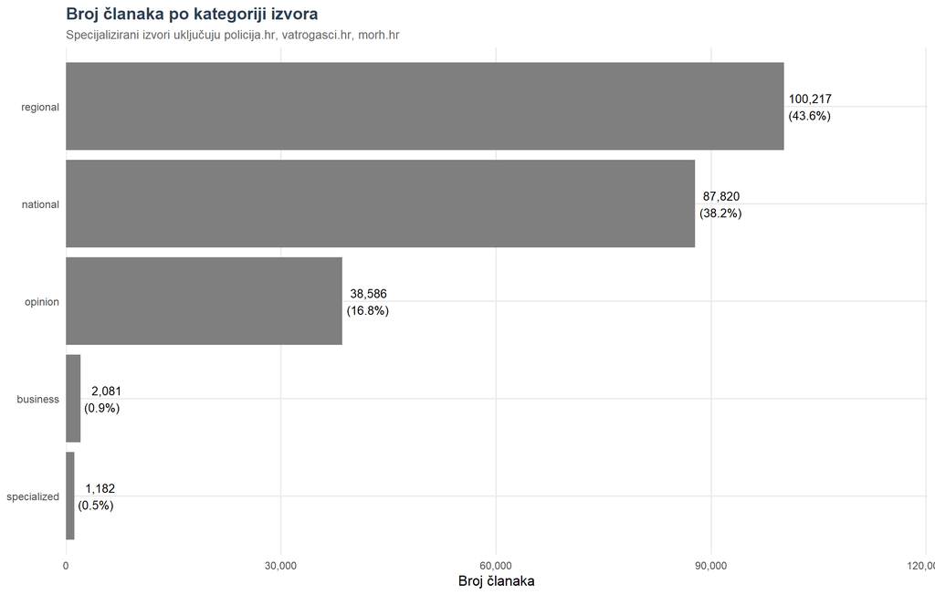

Distribucija članaka po kategorijama izvora

## 3.3 Top 20 izvora

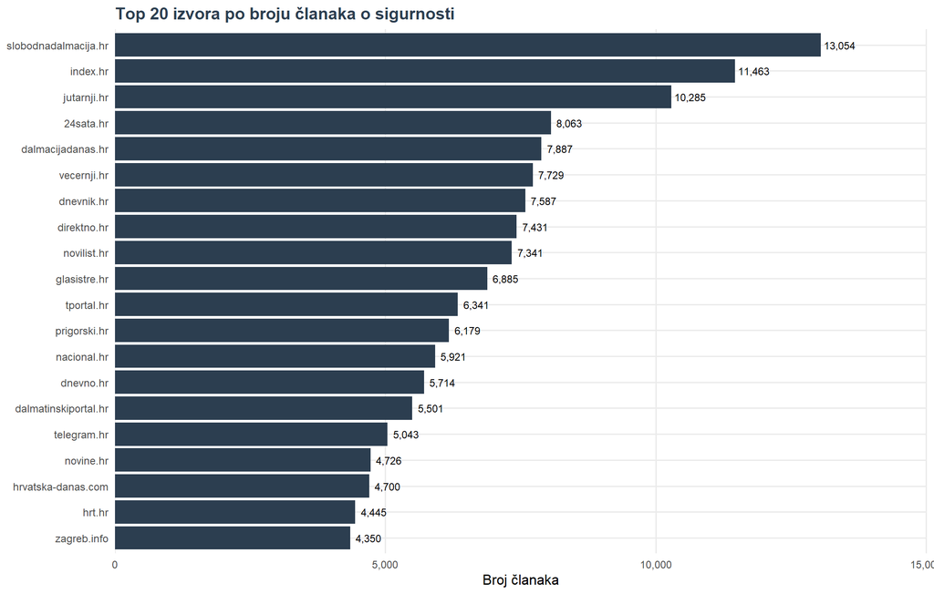

20 najaktivnijih izvora

## 3.4 Distribucija duljine teksta

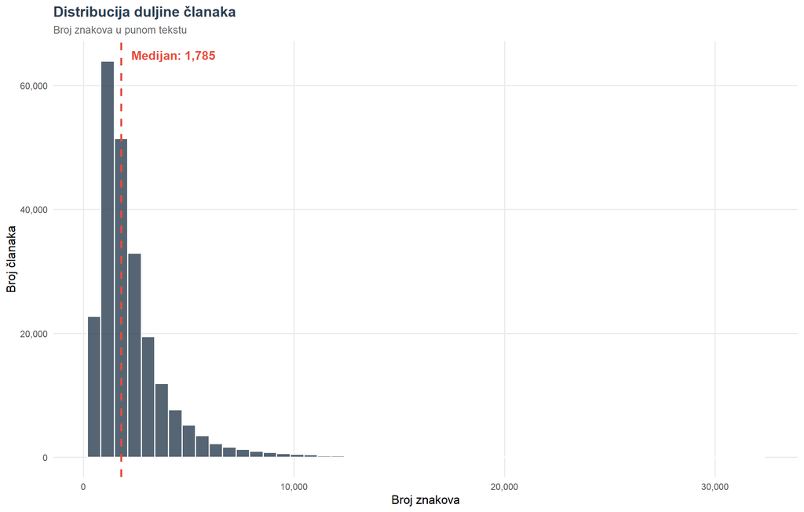

Distribucija duljine članaka

# 4 Semantička taksonomija

## 4.1 Hijerarhijska struktura pojmova

Semantički rječnik se temelji na pojmovima identificiranima u procesu filtriranja članaka. Pojmovi se definiraju pomoću korijena riječi (stem) kako bi se osigurala šira morfološka pokrivenost hrvatskog jezika. Taksonomija se organizira u 12 kategorija koje obuhvaćaju različite aspekte sigurnosnih prijetnji i institucionalnog odgovora u hrvatskom kontekstu.

**Detaljna metodologija semantičke taksonomije**

**Princip konstrukcije rječnika:**

1. Kategorije predstavljaju konceptualno različite aspekte sigurnosti
2. Regex uzorci se koriste za fleksibilno prepoznavanje morfoloških varijanti
3. Korijenski oblici osiguravaju prepoznavanje svih padežnih i glagolskih oblika

**Morfološka pokrivenost:**

Za hrvatski jezik koji ima bogatu morfologiju, koriste se korijenski oblici s opcionalnim nastavcima: `ubojstv[a-zčćžšđ]*` prepoznaje ubojstvo, ubojstva, ubojstvom. Alternativni oblici za palatalizaciju: `[sš]`, `[cč]`, `[zž]}`. Wildcard znakovi: `.{0,15}` dopušta do 15 bilo kojih znakova između riječi.

**Formula za brojanje:**

$$\text{count}_{c,d} = \sum_{p \in P_c} \text{matches}(p, d)$$

gdje je $P_c$ skup regex uzoraka za kategoriju $c$, a $d$ je tekst dokumenta.

Pregled rječnika semantičkih pojmova za sigurnost

| Kategorija | Broj pojmova | Primjeri regex uzoraka |
| --- | --- | --- |
| Nasilni kriminal | 9 | ubojstv[a-zčćžšđ]*, ubij[a-zčćžšđ]* |
| Imovinski kriminal | 8 | pljačk[a-zčćžšđ]*, razbojni[sš]tv[a-zčćžšđ]* |
| Organizirani kriminal | 9 | organiziran[a-zčćžšđ]*.{0,10}kriminal, kriminaln[a-zčćžšđ]*.{0,10}(skupin&#124;organ&#124;mre[zž]) |
| Uhićenja i pritvori | 6 | uhi[cć]en[a-zčćžšđ]*, priveden[a-zčćžšđ]* |
| Tužiteljstvo i sudstvo | 10 | \bdorh\b, dr[zž]avn[a-zčćžšđ]*.{0,10}odvjetni[sš]tv |
| Prometne nesreće | 9 | prometn[a-zčćžšđ]*.{0,10}nesre[cć], sudar[a-zčćžšđ]* |
| Požari | 9 | po[zž]ar[a-zčćžšđ]*, [sš]umski.{0,5}po[zž]ar |
| Prirodne katastrofe | 11 | potres[a-zčćžšđ]*, magnitud[a-zčćžšđ]* |
| Hitne službe | 8 | \bhgss\b, hrvatska gorska slu[zž]ba |
| Terorizam | 7 | teroriz[a-zčćžšđ]*, terorist[a-zčćžšđ]* |
| Cyber kriminal | 7 | cyber.{0,5}(napad&#124;kriminal&#124;sigurnost), hakersk[a-zčćžšđ]*.{0,10}napad |
| Žrtve i štete | 10 | (smrtn&#124;smrtno).{0,5}stradal, [zž]rtv[a-zčćžšđ]* |

## 4.2 Brojanje semantičkih pojmova

## 4.3 Dinamika semantičkih kategorija

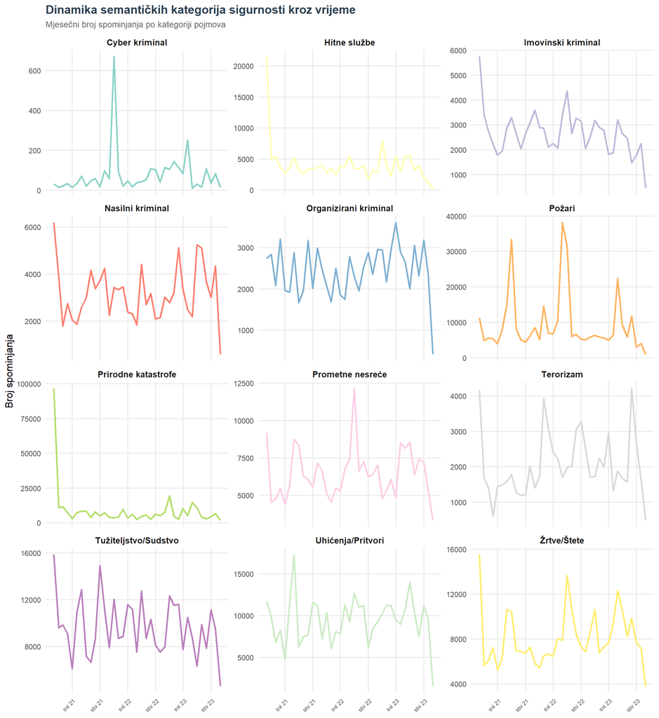

Dinamika semantičkih kategorija kroz vrijeme

# 5 Konstrukcija indeksa

### 5.0.1 Violent Crime Index (VCI)

VCI kvantificira intenzitet medijskog diskursa o nasilnim kaznenim djelima u hrvatskim medijima. Konstrukcija se temelji na prebrojavanju pojavljivanja korijena riječi koje signaliziraju nasilni kriminal, kao što su ubojstv, silovanj, nasilj, napad i slično. Suma tih pojavljivanja normalizira se brojem članaka kako bi se dobila prosječna mjesečna frekvencija pojmova nasilnog kriminala. Rezultat se skalira na raspon 0 do 100 standardnom min max normalizacijom. Povišene vrijednosti VCI indeksa indiciraju razdoblja intenzivnog medijskog izvještavanja o nasilnom kriminalu.

**Detaljna metodologija VCI indeksa**

**Formula:**

$$\text{VCI}_t = \text{normalize}_{0-100}\left(\frac{\text{count}_{nasilni,t}}{N_t}\right)$$

**Uključeni pojmovi:** ubojstvo, fizički napad, napad nožem/oružjem, silovanje, seksualno nasilje, obiteljsko nasilje

**Interpretacija:** Visoke vrijednosti ukazuju na intenzivan medijski diskurs o nasilnom kriminalu.

### 5.0.2 Property Crime Index (PCI)

PCI mjeri intenzitet medijskog diskursa o imovinskom kriminalu uključujući krađe, provale, pljačke i vandalizam. Indeks se konstruira prebrojavanjem pojavljivanja relevantnih pojmova normaliziranih ukupnim brojem članaka u mjesecu. Visoke vrijednosti indiciraju pojačano izvještavanje o imovinskim kaznenim djelima.

**Detaljna metodologija PCI indeksa**

**Formula:**

$$\text{PCI}_t = \text{normalize}_{0-100}\left(\frac{\text{count}_{imovinski,t}}{N_t}\right)$$

**Uključeni pojmovi:** pljačka, razbojništvo, krađa, provale, vandalizam, palež

### 5.0.3 Organized Crime Index (OCI)

OCI prati intenzitet medijskog diskursa o organiziranom kriminalu, krijumčarenju, trgovini ljudima i narkomafiji. Konstrukcija slijedi istu metodologiju normalizacije broja pojavljivanja relevantnih pojmova. Povišene vrijednosti mogu indicirati velike policijske akcije protiv organiziranih kriminalnih skupina.

**Detaljna metodologija OCI indeksa**

**Formula:**

$$\text{OCI}_t = \text{normalize}_{0-100}\left(\frac{\text{count}_{organizirani,t}}{N_t}\right)$$

**Uključeni pojmovi:** organizirani kriminal, krijumčarenje, trgovina ljudima, narkokartel, mafija, droga

### 5.0.4 Prosecution and Arrests Index (PAI)

PAI mjeri intenzitet diskursa o uhićenjima, pritvorima i radu pravosudnih institucija. Indeks kombinira pojmove vezane uz policijske akcije (uhićenja, pritvori) i tužiteljske aktivnosti (DORH, USKOK, optužnice). Visoke vrijednosti signaliziraju intenzivne policijske i pravosudne aktivnosti.

**Detaljna metodologija PAI indeksa**

**Formula:**

$$\text{PAI}_t = \text{normalize}_{0-100}\left(\frac{\text{count}_{uhicenja,t} + \text{count}_{tuziteljstvo,t}}{N_t}\right)$$

**Uključeni pojmovi:** uhićen, priveden, pritvor, DORH, USKOK, PNUSKOK, optužnica, kaznena prijava, presuda

### 5.0.5 Traffic Accident Index (TAI)

TAI prati intenzitet medijskog diskursa o prometnim nesrećama i sigurnosti u prometu. Indeks pokazuje izražene sezonske obrasce s vrhovima tijekom ljetne sezone i blagdana kada je promet intenzivniji.

**Detaljna metodologija TAI indeksa**

**Formula:**

$$\text{TAI}_t = \text{normalize}_{0-100}\left(\frac{\text{count}_{prometne,t}}{N_t}\right)$$

**Uključeni pojmovi:** prometna nesreća, sudar, slijetanje, poginuo u prometu, alkohol za volanom, autocesta

### 5.0.6 Fire Index (FRI)

FRI mjeri intenzitet diskursa o požarima i vatrogasnim intervencijama. Indeks pokazuje snažan sezonski obrazac s vrhovima u ljetnim mjesecima kada su šumski požari najučestaliji.

**Detaljna metodologija FRI indeksa**

**Formula:**

$$\text{FRI}_t = \text{normalize}_{0-100}\left(\frac{\text{count}_{pozari,t}}{N_t}\right)$$

**Uključeni pojmovi:** požar, šumski požar, stambeni požar, vatrogasci, JVP, DVD, gašenje požara

### 5.0.7 Natural Disaster Index (NDI)

NDI prati intenzitet diskursa o potresima, poplavama, olujama i drugim prirodnim nepogodama. Vrhovi koincidiraju s velikim prirodnim katastrofama poput petrinjskog potresa 2020. godine.

**Detaljna metodologija NDI indeksa**

**Formula:**

$$\text{NDI}_t = \text{normalize}_{0-100}\left(\frac{\text{count}_{katastrofe,t}}{N_t}\right)$$

**Uključeni pojmovi:** potres, magnituda, Richter, seizmološki, poplava, bujica, oluja, nevrijeme, klizište, odron

### 5.0.8 Emergency Services Index (ESI)

ESI mjeri intenzitet diskursa o radu hitnih službi uključujući HGSS, civilnu zaštitu i intervencije spašavanja. Povišene vrijednosti indiciraju razdoblja pojačanih intervencija i kriznih situacija.

**Detaljna metodologija ESI indeksa**

**Formula:**

$$\text{ESI}_t = \text{normalize}_{0-100}\left(\frac{\text{count}_{hitne,t}}{N_t}\right)$$

**Uključeni pojmovi:** HGSS, Hrvatska gorska služba spašavanja, civilna zaštita, evakuacija, spašavanje

### 5.0.9 Terrorism Index (TRI)

TRI prati intenzitet diskursa o terorizmu, radikalizaciji i sigurnosnim prijetnjama. Indeks je generalno nizak u hrvatskom kontekstu s povremenim skokovima vezanim uz međunarodne događaje.

**Detaljna metodologija TRI indeksa**

**Formula:**

$$\text{TRI}_t = \text{normalize}_{0-100}\left(\frac{\text{count}_{terorizam,t}}{N_t}\right)$$

**Uključeni pojmovi:** terorizam, teroristi, radikalizacija, eksplozija, bomba

### 5.0.10 Cyber Crime Index (CYI)

**Detaljna metodologija CYI indeksa**

**Formula:**

$$\text{CYI}_t = \text{normalize}_{0-100}\left(\frac{\text{count}_{cyber,t}}{N_t}\right)$$

**Uključeni pojmovi:** cyber napad, hakerski napad, krađa podataka, ransomware, phishing, malware

### 5.0.11 Composite Security Index (CSI)

CSI predstavlja kompozitni indeks sigurnosti koji agregira sve pojedinačne indekse u jednu mjeru ukupnog sigurnosnog diskursa. Izračunava se kao jednostavni prosjek svih 11 specijaliziranih indeksa. Visoke vrijednosti indiciraju razdoblja intenzivnog medijskog izvještavanja o sigurnosnim temama općenito.

**Detaljna metodologija CSI indeksa**

**Formula:**

$$\text{CSI}_t = \frac{1}{11} \sum_{i=1}^{11} \text{Indeks}_{i,t}$$

**Interpretacija vrijednosti:**

Raspon 0 do 25 indicira nisku razinu sigurnosnog diskursa. Raspon 25 do 50 indicira umjerenu razinu. Raspon 50 do 75 indicira visoku razinu. Raspon 75 do 100 indicira vrlo visoku razinu tipičnu za krizna razdoblja i velike incidente.

## 5.1 Opis indeksa

Pregled konstruiranih indeksa

| Indeks | Naziv | Opis |
| --- | --- | --- |
| VCI | Violent Crime Index | Nasilni kriminal (ubojstva, napadi, nasilje) |
| PCI | Property Crime Index | Imovinski kriminal (krađe, provale, pljačke) |
| OCI | Organized Crime Index | Organizirani kriminal i krijumčarenje |
| PAI | Prosecution and Arrests Index | Uhićenja, pritvori i pravosudne aktivnosti |
| TAI | Traffic Accident Index | Prometne nesreće i sigurnost u prometu |
| FRI | Fire Index | Požari i vatrogasne intervencije |
| NDI | Natural Disaster Index | Prirodne katastrofe (potresi, poplave, oluje) |
| ESI | Emergency Services Index | Rad hitnih službi i spašavanje |
| TRI | Terrorism Index | Terorizam i radikalizacija |
| CYI | Cyber Crime Index | Cyber kriminal i digitalna sigurnost |
| CSI | Composite Security Index | Kompozitni indeks svih kategorija |

# 6 Vizualizacija indeksa

## 6.1 Glavni indeksi

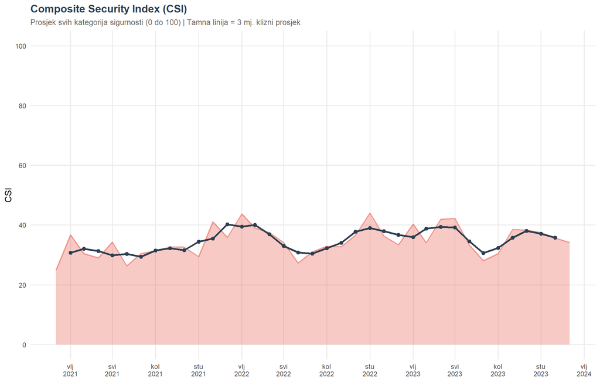

Composite Security Index (CSI)

## 6.2 Indeksi kriminala

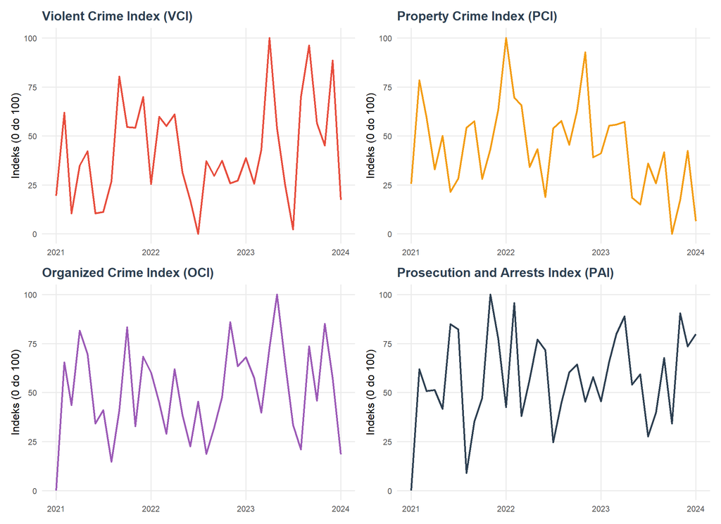

Indeksi kriminala: VCI, PCI, OCI, PAI

## 6.3 Indeksi nesreća i katastrofa

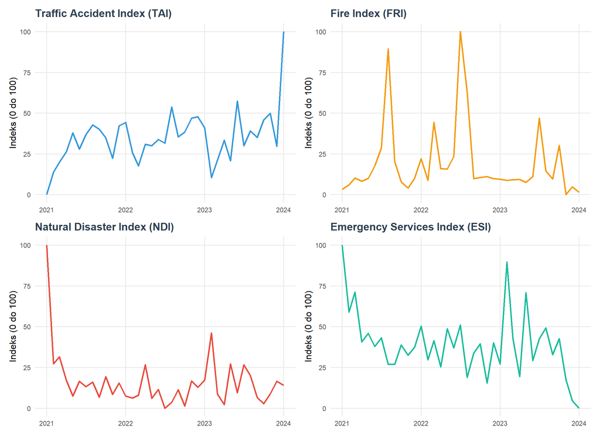

Indeksi nesreća i katastrofa: TAI, FRI, NDI, ESI

## 6.4 Indeksi terorizma i cyber kriminala

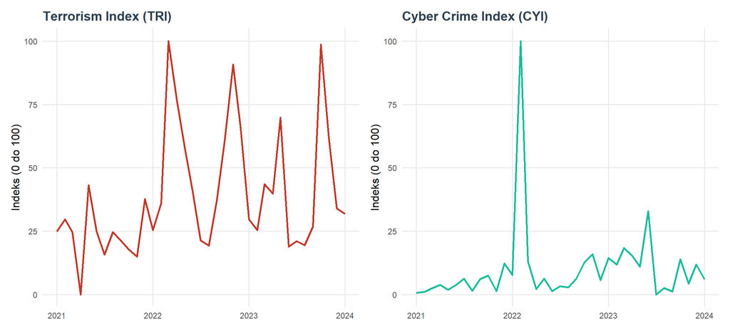

Terrorism Index (TRI) i Cyber Crime Index (CYI)

## 6.5 Tablica indeksa

Indeksi sigurnosti: zadnjih 12 mjeseci

| Mjesec | Broj članaka | CSI | VCI | TAI | FRI | NDI | PAI |
| --- | --- | --- | --- | --- | --- | --- | --- |
| vlj 2023 | 6,669 | 40.3 | 25.6 | 10.5 | 8.8 | 46.1 | 65.7 |
| ožu 2023 | 6,079 | 34.0 | 42.8 | 21.2 | 9.2 | 8.7 | 79.9 |
| tra 2023 | 5,740 | 42.0 | 100.0 | 33.4 | 9.3 | 2.1 | 88.8 |
| svi 2023 | 5,605 | 42.2 | 53.9 | 20.8 | 7.5 | 27.0 | 54.0 |
| lip 2023 | 6,049 | 33.3 | 24.8 | 57.3 | 11.1 | 9.5 | 59.3 |
| srp 2023 | 8,112 | 28.0 | 2.3 | 30.0 | 47.0 | 26.5 | 27.5 |
| kol 2023 | 7,499 | 30.4 | 69.9 | 39.1 | 14.6 | 20.0 | 39.6 |
| ruj 2023 | 5,889 | 38.5 | 96.2 | 35.1 | 9.7 | 6.5 | 67.6 |
| lis 2023 | 5,986 | 38.3 | 56.4 | 46.0 | 30.2 | 2.7 | 34.2 |
| stu 2023 | 5,557 | 37.4 | 45.1 | 49.8 | 0.0 | 8.8 | 90.4 |
| pro 2023 | 5,310 | 35.7 | 88.5 | 29.7 | 4.8 | 16.4 | 73.5 |
| sij 2024 | 1,633 | 34.1 | 17.3 | 100.0 | 1.5 | 14.0 | 79.9 |

# 7 Sektorska analiza

## 7.1 Dinamika po sektorima

[figure not shown]

Dinamika sigurnosnih kategorija po sektorima

## 7.2 Heatmapa sektorske aktivnosti

[figure not shown]

Heatmapa intenziteta sigurnosnih kategorija kroz vrijeme

## 7.3 Korelacijska struktura

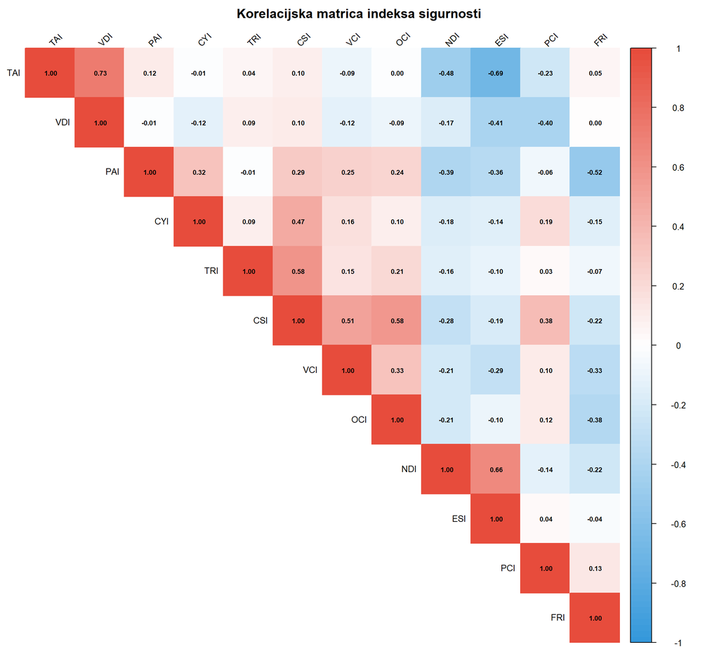

Korelacijska matrica indeksa sigurnosti

# 8 Volatilnost i momentum

## 8.1 Konstrukcija volatilnosti i momentuma

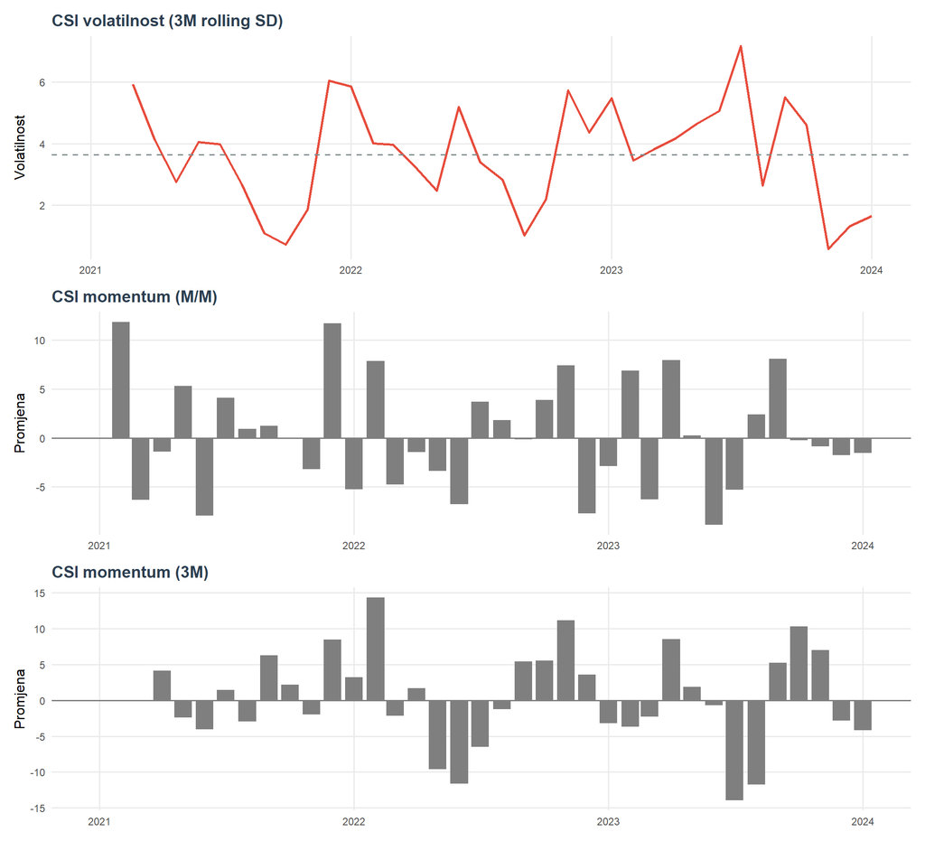

CSI volatilnost i momentum

[figure not shown]

Standardizirani indeksi volatilnosti i momentuma

# 9 Koncentracija tema

## 9.1 Konstrukcija mjera koncentracije

**Metodologija HHI indeksa**

Herfindahl Hirschman Index (HHI) mjeri koncentraciju tema u medijskom prostoru. Izračunava se kao suma kvadrata udjela svake kategorije. Vrijednosti bliže 1 indiciraju visoku koncentraciju (dominacija jedne teme), dok vrijednosti bliže 0 indiciraju ravnomjerniju raspodjelu pozornosti.

**Formula:**

$$\text{HHI}_t = \sum_{i=1}^{n} s_{i,t}^2$$

gdje je $s_{i,t}$ udio kategorije $i$ u ukupnom broju spominjanja u mjesecu $t$.

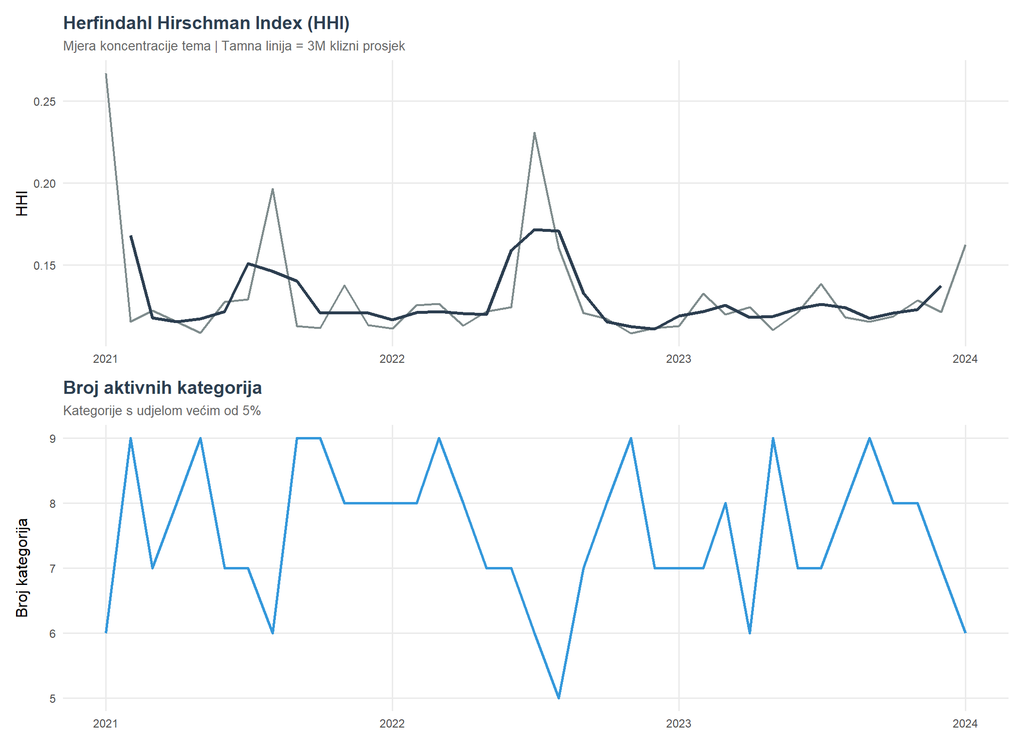

Koncentracija tema (HHI) i broj aktivnih kategorija

# 10 Korelacije između indeksa

Korelacije pojedinačnih indeksa s Composite Security Index

| Indeks | Korelacija s CSI |
| --- | --- |
| TRI | 0.581 |
| OCI | 0.580 |
| VCI | 0.507 |
| CYI | 0.468 |
| PCI | 0.379 |
| PAI | 0.288 |
| VDI | 0.103 |
| TAI | 0.098 |
| ESI | -0.190 |
| FRI | -0.223 |
| NDI | -0.281 |

# 11 Export

# 12 Sažetak

Sažetak ključnih nalaza analize

| Nalaz | Vrijednost |
| --- | --- |
| Ukupno analiziranih članaka | 229,886 |
| Vremenski raspon analize | 01/2021 do 01/2024 |
| Broj izvora | 113 |
| Vrh CSI indeksa | studeni 2022 |
| Vrijednost vrha | 44 |
| Dominantna kategorija | Uhićenja/Progon |
| Prosječna vrijednost | 57.5 |
| Prosječni CSI | 34.5 |
| Standardna devijacija CSI | 4.9 |

*Izvještaj generiran: 2026-01-02 13:27:07.294504*

*GIMES Research | Analiza medijske pokrivenosti sigurnosti i stabilnosti v2.0*